# Robustness Analysis: MLB Hot-Hand Effect

Shenwei Zhang

```r
knitr::opts_chunk$set(
  echo = TRUE,
  message = FALSE,
  warning = FALSE
)

library(dplyr)
library(tidyr)
```

```r
library(readr)
library(ggplot2)
library(zoo)
```

# 1 Purpose

The primary analysis identified unusually large within-season variation in Michael Harris II’s 2025 batting performance relative to a season-specific i.i.d. Bernoulli null model. That analysis used a 25-at-bat rolling batting average and the variance of the rolling series as the primary streakiness statistic.

These choices define one reasonable statistical specification, but they are not unique. The purpose of this robustness analysis is therefore to evaluate whether the substantive findings persist under alternative reasonable analytical choices.

The analysis focuses on three sources of specification sensitivity:

1. the length of the rolling batting-average window;
2. the statistic used to quantify temporal variation or dependence; and
3. the assumptions used to construct the no-streakiness benchmark.

The goal is not to search across specifications for statistically significant results. Instead, the alternative specifications are used as sensitivity checks for conclusions established in the primary analysis.

# 2 Reconstruct Analysis Data

```r
raw_data <- readr::read_csv(
  "../data/savant_data.csv",
  show_col_types = FALSE
)
```

## 2.1 Load Statcast Data

```r
source("../data/prepare_analysis_data.R")

dim(ab_data)
```

```
## [1] 1970  122
```

## 2.2 Construct Official At-Bat Dataset

```r
ab_data %>%
  group_by(game_year) %>%
  summarise(
    official_ab = n(),
    hits = sum(hit),
    batting_average = mean(hit),
    .groups = "drop"
  )
```

```
## # A tibble: 4 × 4
##   game_year official_ab  hits batting_average
##       <dbl>       <int> <int>           <dbl>
## 1      2022         414   123           0.297
## 2      2023         505   148           0.293
## 3      2024         440   116           0.264
## 4      2025         611   152           0.249
```

# 3 Rolling-Window Sensitivity

## 3.1 Alternative Window Lengths

The primary analysis uses a 25-at-bat rolling window to summarize local batting performance. Because the choice of window length determines the time scale over which performance variation is measured, the analysis is repeated using several alternative window lengths.

The sensitivity analysis considers windows of 10, 15, 25, and 30 official at-bats:

$$w \in \{10, 15, 25, 30\}.$$

```r
window_sizes <- c(10, 15, 25, 30)

window_sizes
```

```
## [1] 10 15 25 30
```

The 25-at-bat window remains the primary specification. The alternative windows are used only to evaluate whether the substantive conclusions are sensitive to the chosen smoothing scale.

## 3.2 Observed Rolling Patterns

For each window length, rolling batting average is recalculated separately within each season. Streakiness is measured using the same statistic as the primary analysis: the variance of the rolling batting-average series,

$$T_y(w) = \operatorname{Var}\left(R_{y,t}^{(w)}\right).$$

Keeping the statistic fixed while changing only the window length allows the sensitivity of the observed variation to the smoothing choice to be evaluated directly.

```r
calculate_observed_streakiness <- function(
  data,
  window
) {

  data %>%
    group_by(game_year) %>%
    arrange(
      game_date,
      game_pk,
      at_bat_number,
      .by_group = TRUE
    ) %>%
    mutate(
      rolling_ba = zoo::rollmean(
        hit,
        k = window,
        fill = NA,
        align = "right"
      )
    ) %>%
    summarise(
      observed_variance = var(
        rolling_ba,
        na.rm = TRUE
      ),
      .groups = "drop"
    ) %>%
    mutate(
      window = window
    )
}
```

```r
observed_window_results <- bind_rows(
  lapply(
    window_sizes,
    function(w) {
      calculate_observed_streakiness(
        data = ab_data,
        window = w
      )
    }
  )
)

observed_window_results
```

```
## # A tibble: 16 × 3
##    game_year observed_variance window
##        <dbl>             <dbl>  <dbl>
##  1      2022           0.0178      10
##  2      2023           0.0236      10
##  3      2024           0.0210      10
##  4      2025           0.0287      10
##  5      2022           0.0111      15
##  6      2023           0.0149      15
##  7      2024           0.0154      15
##  8      2025           0.0214      15
##  9      2022           0.00679     25
## 10      2023           0.00998     25
## 11      2024           0.0102      25
## 12      2025           0.0146      25
## 13      2022           0.00577     30
## 14      2023           0.00929     30
## 15      2024           0.00848     30
## 16      2025           0.0127      30
```

Observed rolling-BA variance changes with the window length, as expected because shorter windows are more responsive to local fluctuations while longer windows smooth the performance series.

Across the specifications, 2025 consistently shows relatively large observed variation. However, raw variances are not directly comparable across window lengths because each window produces a different scale of natural variability. Statistical interpretation therefore requires a separate Monte Carlo null distribution for each season-window combination.

## 3.3 Monte Carlo Tests Across Windows

**For each window, is the observed variance unusually large relative to what that same window would produce under the Bernoulli null?**

### 3.3.1 create the simulation function

Raw rolling-BA variances are not directly comparable across window lengths. Therefore, a separate Monte Carlo null distribution is constructed for each season-window combination.

For each simulation, a season-length sequence of independent Bernoulli outcomes is generated using the observed season batting average. The same rolling window and variance statistic are then applied to the simulated sequence, ensuring that each observed statistic is compared with an appropriate null benchmark.

```r
simulate_streakiness <- function(
  n_ab,
  p_hit,
  window
) {

  simulated_hits <- rbinom(
    n = n_ab,
    size = 1,
    prob = p_hit
  )

  simulated_rolling_ba <- zoo::rollmean(
    simulated_hits,
    k = window,
    fill = NA,
    align = "right"
  )

  var(
    simulated_rolling_ba,
    na.rm = TRUE
  )
}
```

### 3.3.2 prepare the simulation parameters for each season

Each simulated season preserves the observed number of official at-bats $n_y$ and season batting average $\hat p_y$. Hit outcomes are then independently generated from $\text{Bernoulli}(\hat p_y)$, preserving the season’s baseline performance while removing the observed temporal structure.

```r
season_summary <- ab_data %>%
  group_by(game_year) %>%
  summarise(
    official_ab = n(),
    hits = sum(hit),
    batting_average = mean(hit),
    .groups = "drop"
  )

# season_summary (same as the mainanalysis infor about this)
# since we only change the window size not the other
```

### 3.3.3 Generate Monte Carlo Simulations

now this part code create all th combinations:
$$4 seasons×4 windows×5000
simulations=80,000$$

For each season-window combination, 5,000 Monte Carlo seasons are generated under the season-specific Bernoulli null model.

The observed and simulated sequences are analyzed using the same rolling window and variance statistic. The observed statistic $T_y^{obs}(w)$ is then compared with the simulated null statistics $T_y^*(w)$ to determine whether the observed variation is unusually large under the no-streakiness benchmark.

```r
n_sim <- 5000

set.seed(123)

window_simulations <- tidyr::crossing(
  season_summary,
  window = window_sizes,
  simulation = seq_len(n_sim)
) %>%
  rowwise() %>%
  mutate(
    simulated_variance = simulate_streakiness(
      n_ab = official_ab,
      p_hit = batting_average,
      window = window
    )
  ) %>%
  ungroup()
```

```r
dim(window_simulations)
```

```
## [1] 80000     7
```

```r
# check the simaltion numbers?
```

## 3.4 Window-Sensitivity Results

For each season-window combination, the observed rolling-BA variance is compared with its corresponding Monte Carlo null distribution. The Monte Carlo p-value is the proportion of simulated statistics at least as large as the observed statistic, using the finite-simulation correction:

$$p_{\mathrm{MC}}
=
\frac{1+\sum_{b=1}^{B} I(T_{y,b}^{*}(w)\geq T_y^{obs}(w))}
{B+1}.$$

### 3.4.1 calculate the 16-values

```r
window_robustness_results <- window_simulations %>%
  left_join(
    observed_window_results,
    by = c("game_year", "window")
  ) %>%
  group_by(
    game_year,
    window
  ) %>%
  summarise(
    observed_variance = first(observed_variance),
    exceedances = sum(
      simulated_variance >= observed_variance
    ),
    n_simulations = n(),
    monte_carlo_p = (
      exceedances + 1
    ) / (
      n_simulations + 1
    ),
    .groups = "drop"
  )

window_robustness_results
```

```
## # A tibble: 16 × 6
##    game_year window observed_variance exceedances n_simulations monte_carlo_p
##        <dbl>  <dbl>             <dbl>       <int>         <int>         <dbl>
##  1      2022     10           0.0178         3800          5000      0.760
##  2      2022     15           0.0111         3882          5000      0.776
##  3      2022     25           0.00679        3259          5000      0.652
##  4      2022     30           0.00577        2872          5000      0.574
##  5      2023     10           0.0236          779          5000      0.156
##  6      2023     15           0.0149         1340          5000      0.268
##  7      2023     25           0.00998         761          5000      0.152
##  8      2023     30           0.00929         395          5000      0.0792
##  9      2024     10           0.0210         1248          5000      0.250
## 10      2024     15           0.0154          720          5000      0.144
## 11      2024     25           0.0102          453          5000      0.0908
## 12      2024     30           0.00848         481          5000      0.0964
## 13      2025     10           0.0287            4          5000      0.00100
## 14      2025     15           0.0214            3          5000      0.000800
## 15      2025     25           0.0146            4          5000      0.00100
## 16      2025     30           0.0127            0          5000      0.000200
```

The 2025 result is robust to the choice of rolling-window length. Across 10-, 15-, 25-, and 30-at-bat windows, the observed rolling-BA variance remains in the extreme upper tail of its corresponding Monte Carlo null distribution, with Monte Carlo p-values ranging from approximately 0.0002 to 0.0010.

In contrast, the 2022–2024 results are substantially less extreme across the tested window lengths. Thus, the unusually large 2025 variation is not driven specifically by the primary 25-at-bat window choice.

### 3.4.2 visualize window sensitivity

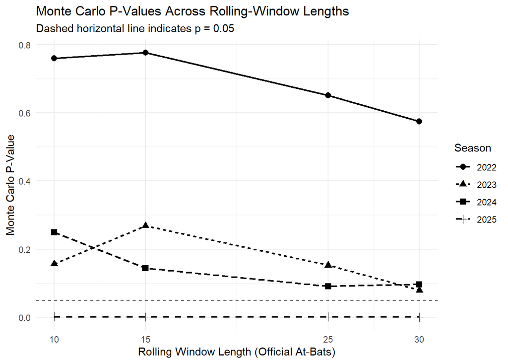

```r
ggplot(
  window_robustness_results,
  aes(
    x = window,
    y = monte_carlo_p,
    group = factor(game_year),
    linetype = factor(game_year),
    shape = factor(game_year)
  )
) +
  geom_line(linewidth = 0.8) +
  geom_point(size = 2.5) +
  geom_hline(
    yintercept = 0.05,
    linetype = "dashed"
  ) +
  scale_x_continuous(
    breaks = window_sizes
  ) +
  labs(
    title = "Monte Carlo P-Values Across Rolling-Window Lengths",
    subtitle = "Dashed horizontal line indicates p = 0.05",
    x = "Rolling Window Length (Official At-Bats)",
    y = "Monte Carlo P-Value",
    linetype = "Season",
    shape = "Season"
  ) +
  theme_minimal()
```

The window-sensitivity analysis shows a clear difference across seasons. The 2022 results remain well within the range expected under the null model, while the 2023 and 2024 results move closer to the upper tail as the window length changes but remain above the 0.05 reference level.

In contrast, the 2025 Monte Carlo p-values remain approximately 0.001 or smaller across all four window lengths. They appear nearly flat at zero in the figure because the y-axis extends to approximately 0.8, not because the p-values are actually zero.

Overall, the unusually large rolling-performance variation observed in 2025 is robust to the choice of 10-, 15-, 25-, or 30-at-bat windows and is therefore not specific to the primary 25-AB specification.

# 4 Alternative Streakiness Statistics

**Does the 2025 result persist when streakiness is measured in a different way?**

## 4.1 Why Variance May Be Insufficient

The primary analysis measures streakiness using the variance of the rolling batting-average series. This captures the overall magnitude of local performance fluctuations, but it does not directly measure how batting outcomes are ordered over time.

Two seasons can have similar rolling-BA variance while exhibiting different temporal patterns. Therefore, alternative statistics are used to test whether the 2025 finding also appears when streakiness is defined through temporal dependence rather than only the magnitude of rolling variation.

## 4.2 Alternative Statistics 1： Lag-1 Autocorrelation

As an alternative to rolling-BA variance, lag-1 autocorrelation measures whether consecutive official at-bat outcomes are temporally related.

For the binary hit sequence $H_1,\ldots,H_n$, the statistic is

$$T_{\text{ACF}}
=
\operatorname{Cor}(H_t,H_{t-1}).$$

Positive values indicate that similar outcomes tend to occur consecutively, while values near zero indicate little linear dependence between adjacent at-bats. This provides a complementary measure of streakiness that focuses on temporal ordering rather than the magnitude of rolling-BA variation.

### 4.2.1 observed lag-1 auto correlation

```r
calculate_lag1 <- function(data) {

  data %>%
    group_by(game_year) %>%
    arrange(
      game_date,
      game_pk,
      at_bat_number,
      .by_group = TRUE
    ) %>%
    summarise(
      observed_lag1 = cor(
        hit[-1],
        hit[-length(hit)]
      ),
      .groups = "drop"
    )
}
```

```r
observed_lag1_results <- calculate_lag1(ab_data)

observed_lag1_results
```

```
## # A tibble: 4 × 2
##   game_year observed_lag1
##       <dbl>         <dbl>
## 1      2022       -0.0189
## 2      2023        0.0972
## 3      2024        0.0307
## 4      2025        0.0449
```

### 4.2.2 monte carlo null distribution for lag-1

**Does the observed lag-1 correlation in 2025 count as the unusually large?**

To isolate sensitivity to the choice of streakiness statistic, the season-specific i.i.d. Bernoulli null model is kept unchanged from the primary analysis.

For each simulated season,

$$H_{i,y}^{*}
\overset{iid}{\sim}
\operatorname{Bernoulli}(\hat p_y),$$

where the observed number of official at-bats and season batting average are preserved. Lag-1 autocorrelation is then calculated for each simulated hit sequence and compared with the observed statistic.

```r
simulate_lag1 <- function(
  n_ab,
  p_hit
) {

  simulated_hits <- rbinom(
    n = n_ab,
    size = 1,
    prob = p_hit
  )

  cor(
    simulated_hits[-1],
    simulated_hits[-length(simulated_hits)]
  )
}
```

### 4.2.3 Monte Carlo Simulation for Lag-1 Autocorrelation

For each season, 5,000 independent hit sequences are generated under the season-specific Bernoulli null model. Each simulated season preserves the observed number of official at-bats and batting average.

$$4 seasons * 5000 simulations = 20000$$

Lag-1 autocorrelation is calculated for every simulated sequence, producing a null distribution that represents the amount of adjacent dependence that could arise by chance under independent batting outcomes.

```r
set.seed(123)

lag1_simulations <- tidyr::crossing(
  season_summary,
  simulation = seq_len(n_sim)
) %>%
  rowwise() %>%
  mutate(
    simulated_lag1 = simulate_lag1(
      n_ab = official_ab,
      p_hit = batting_average
    )
  ) %>%
  ungroup()
```

```r
# check it
dim(lag1_simulations)
```

```
## [1] 20000     6
```

```r
lag1_simulations %>%
  count(game_year)
```

```
## # A tibble: 4 × 2
##   game_year     n
##       <dbl> <int>
## 1      2022  5000
## 2      2023  5000
## 3      2024  5000
## 4      2025  5000
```

### 4.2.4 Monte Carlo Results

For each season, the observed lag-1 autocorrelation is compared with the distribution of lag-1 autocorrelations generated under the i.i.d. Bernoulli null model.

Because the hot-hand hypothesis corresponds to positive temporal dependence, the upper-tail Monte Carlo p-value is

$$p_{\mathrm{MC}}
=
\frac{
1+\sum_{b=1}^{B}
I(T_{\mathrm{ACF},b}^{*}\geq T_{\mathrm{ACF}}^{obs})
}{
B+1
}.$$

A small p-value indicates that the observed positive lag-1 dependence would be unusual under independent batting outcomes.

```r
lag1_results <- lag1_simulations %>%
  left_join(
    observed_lag1_results,
    by = "game_year"
  ) %>%
  group_by(game_year) %>%
  summarise(
    observed_lag1 = first(observed_lag1),

    exceedances = sum(
      simulated_lag1 >= observed_lag1
    ),

    n_simulations = n(),

    monte_carlo_p = (
      exceedances + 1
    ) / (
      n_simulations + 1
    ),

    .groups = "drop"
  )

lag1_results
```

```
## # A tibble: 4 × 5
##   game_year observed_lag1 exceedances n_simulations monte_carlo_p
##       <dbl>         <dbl>       <int>         <int>         <dbl>
## 1      2022       -0.0189        3140          5000        0.628
## 2      2023        0.0972          58          5000        0.0118
## 3      2024        0.0307        1128          5000        0.226
## 4      2025        0.0449         617          5000        0.124
```

Lag-1 autocorrelation produces a different pattern from the rolling-variance statistic. The 2025 season has a positive observed lag-1 correlation ($r = 0.045$), but the corresponding Monte Carlo p-value is approximately 0.124. Thus, the unusually large rolling-performance variation identified for 2025 does not appear to be driven by unusually strong immediate at-bat-to-at-bat dependence.

In contrast, 2023 exhibits the largest observed lag-1 autocorrelation ($r = 0.097$) and a relatively small upper-tail Monte Carlo p-value ($p \approx 0.012$). This illustrates that different streakiness statistics capture different aspects of temporal structure: rolling variance measures the magnitude of local performance fluctuations, whereas lag-1 autocorrelation measures dependence between consecutive at-bat outcomes.

## 4.3 Alternative Statistic 2 — Longest Hit Run

As a second alternative measure, the longest hit run captures the maximum number of consecutive official at-bats resulting in hits within a season.

$$T_{\text{run}}
=
\max\{\text{length of consecutive hit sequences}\}.$$

Unlike rolling-BA variance, which measures the magnitude of local performance fluctuations, and lag-1 autocorrelation, which measures average dependence between adjacent outcomes, the longest-run statistic focuses on extreme clustering of consecutive hits.

```r
# define the statistic
calculate_longest_hit_run <- function(hit_sequence) {

  runs <- rle(hit_sequence)

  max(
    runs$lengths[runs$values == 1]
  )
}
```

```r
# use it in the real 2022-2025 data
observed_run_results <- ab_data %>%
  group_by(game_year) %>%
  arrange(
    game_date,
    game_pk,
    at_bat_number,
    .by_group = TRUE
  ) %>%
  summarise(
    observed_longest_run =
      calculate_longest_hit_run(hit),
    .groups = "drop"
  )

observed_run_results
```

```
## # A tibble: 4 × 2
##   game_year observed_longest_run
##       <dbl>                <int>
## 1      2022                    4
## 2      2023                    5
## 3      2024                    5
## 4      2025                    6
```

### 4.3.1 Monte Carlo simulate longest hit runs

The observed longest hit run increases from four consecutive hits in 2022 to six in 2025. However, the raw run length alone does not indicate whether such clustering is unusual, because seasons differ in both the number of official at-bats and baseline batting average.

Therefore, the observed longest run is compared with season-specific Monte Carlo null distributions generated under the same i.i.d. Bernoulli model used in the primary analysis.

```r
simulate_longest_hit_run <- function(
  n_ab,
  p_hit
) {

  simulated_hits <- rbinom(
    n = n_ab,
    size = 1,
    prob = p_hit
  )

  calculate_longest_hit_run(
    simulated_hits
  )
}
```

$$4 sesons * 5000 = 20000$$

```r
set.seed(123)

run_simulations <- tidyr::crossing(
  season_summary,
  simulation = seq_len(n_sim)
) %>%
  rowwise() %>%
  mutate(
    simulated_longest_run =
      simulate_longest_hit_run(
        n_ab = official_ab,
        p_hit = batting_average
      )
  ) %>%
  ungroup()
```

```r
run_simulations %>%
  count(game_year)
```

```
## # A tibble: 4 × 2
##   game_year     n
##       <dbl> <int>
## 1      2022  5000
## 2      2023  5000
## 3      2024  5000
## 4      2025  5000
```

### 4.3.2 Monte Carlo Results for Longest Hit Run

For each season, the observed longest hit run is compared with the distribution of longest runs generated under the i.i.d. Bernoulli null model.

The upper-tail Monte Carlo p-value is

$$p_{\mathrm{MC}}
=
\frac{
1+\sum_{b=1}^{B}
I(T_{\mathrm{run},b}^{*}\geq T_{\mathrm{run}}^{obs})
}{
B+1
}.$$

A small p-value indicates that a hit run at least as long as the observed run would be unusual under independent batting outcomes.

```r
run_results <- run_simulations %>%
  left_join(
    observed_run_results,
    by = "game_year"
  ) %>%
  group_by(game_year) %>%
  summarise(
    observed_longest_run =
      first(observed_longest_run),

    exceedances = sum(
      simulated_longest_run >=
        observed_longest_run
    ),

    n_simulations = n(),

    monte_carlo_p = (
      exceedances + 1
    ) / (
      n_simulations + 1
    ),

    .groups = "drop"
  )

run_results
```

```
## # A tibble: 4 × 5
##   game_year observed_longest_run exceedances n_simulations monte_carlo_p
##       <dbl>                <int>       <int>         <int>         <dbl>
## 1      2022                    4        4513          5000        0.903
## 2      2023                    5        2632          5000        0.526
## 3      2024                    5        1683          5000        0.337
## 4      2025                    6         498          5000        0.0998
```

### 4.3.3 Summary

The longest-hit-run statistic provides weaker evidence of unusual consecutive-hit clustering than the primary rolling-variance analysis. The longest observed run increased from four hits in 2022 to six hits in 2025, but a run of at least six hits occurred in 498 of the 5,000 simulated 2025 seasons, corresponding to a Monte Carlo p-value of approximately 0.100.

Together with the lag-1 autocorrelation results, this suggests that the strong 2025 rolling-variance result is not explained simply by unusually strong immediate hit-to-hit dependence or by a single exceptionally long run of consecutive hits. Instead, the evidence appears more consistent with unusual variation in performance over a broader time scale.

# 5 Null-Model Sensitivity

## 5.1 Limitations of Constant-p Bernoulli Null

The primary analysis uses a season-specific i.i.d. Bernoulli null model,

$$H_{i,y}^{*}
\overset{iid}{\sim}
\operatorname{Bernoulli}(\hat p_y),$$

which assumes that every official at-bat within a season has the same hit probability and that outcomes are independent over time.

This provides a transparent benchmark for no temporal structure, but it simplifies the actual baseball data-generating process. In observational game data, the probability of a hit may vary across at-bats because of changing game contexts, opponents, pitch characteristics, and other observed or unobserved factors.

Therefore, an unusually large statistic relative to the i.i.d. Bernoulli null establishes that the observed temporal pattern is inconsistent with this particular constant-probability benchmark. It does not, by itself, identify a causal hot-hand effect.

The following sensitivity analyses therefore consider alternative null models that preserve more structure from the observed data while removing the specific temporal ordering associated with streakiness.

## 5.2 Alternative Benchmarks

### 5.2.1 Within-Season Permutation Null

As an alternative to the i.i.d. Bernoulli benchmark, a within-season permutation null preserves the exact observed hit and non-hit outcomes within each season while randomly reordering their temporal positions.

For season $y$, each permutation therefore preserves the number of official at-bats and the total number of hits exactly, but removes the observed ordering of those outcomes.

This null asks whether the observed rolling-performance variation is unusual conditional on the season’s realized outcomes, rather than relative to newly generated Bernoulli outcomes. The permutation procedure is used as a statistical null benchmark and should not be interpreted as a randomized experimental assignment mechanism.

```r
simulate_permutation_variance <- function(
  hit_sequence,
  window = 25
) {

  permuted_hits <- sample(
    hit_sequence,
    size = length(hit_sequence),
    replace = FALSE
  )

  permuted_rolling_ba <- zoo::rollmean(
    permuted_hits,
    k = window,
    fill = NA,
    align = "right"
  )

  var(
    permuted_rolling_ba,
    na.rm = TRUE
  )
}
```

#### 5.2.1.1 prepare the observed hit sequences

```r
season_sequences <- ab_data %>%
  arrange(
    game_year,
    game_date,
    game_pk,
    at_bat_number
  ) %>%
  group_by(game_year) %>%
  summarise(
    hit_sequence = list(hit),
    .groups = "drop"
  )

season_sequences
```

```
## # A tibble: 4 × 2
##   game_year hit_sequence
##       <dbl> <list>
## 1      2022 <int [414]>
## 2      2023 <int [505]>
## 3      2024 <int [440]>
## 4      2025 <int [611]>
```

#### 5.2.1.2 Generate 5000 permutations per season

For each season, the observed hit sequence is randomly permuted 5,000 times. Each permutation preserves the exact number of hits and non-hits but changes their temporal ordering.

For every permuted sequence, the primary 25-at-bat rolling batting average and its variance are recalculated. This produces a season-specific permutation null distribution for the primary streakiness statistic.

```r
set.seed(123)

permutation_simulations <- tidyr::crossing(
  season_sequences,
  simulation = seq_len(n_sim)
) %>%
  rowwise() %>%
  mutate(
    permuted_variance =
      simulate_permutation_variance(
        hit_sequence = hit_sequence,
        window = 25
      )
  ) %>%
  ungroup()
```

```r
# check it
permutation_simulations %>%
  count(game_year)
```

```
## # A tibble: 4 × 2
##   game_year     n
##       <dbl> <int>
## 1      2022  5000
## 2      2023  5000
## 3      2024  5000
## 4      2025  5000
```

```r
test_sequence <- season_sequences %>%
  filter(game_year == 2025) %>%
  pull(hit_sequence) %>%
  .[[1]]

test_permutation <- sample(
  test_sequence,
  replace = FALSE
)

sum(test_sequence)
```

```
## [1] 152
```

```r
sum(test_permutation)
```

```
## [1] 152
```

#### 5.2.1.3 permutation simulate test results

For each season, the observed 25-at-bat rolling-BA variance is compared with the distribution obtained from 5,000 random permutations of the observed hit sequence.

The permutation p-value is

$$p_{\mathrm{perm}}
=
\frac{
1+\sum_{b=1}^{B}
I(T_{y,b}^{\mathrm{perm}}\geq T_y^{obs})
}{
B+1
}.$$

A small permutation p-value indicates that the observed temporal arrangement of hits produces greater rolling-performance variation than would typically occur under random reorderings of the same season’s observed outcomes.

```r
observed_primary_variance <- observed_window_results %>%
  filter(window == 25) %>%
  select(
    game_year,
    observed_variance
  )
```

```r
permutation_results <- permutation_simulations %>%
  left_join(
    observed_primary_variance,
    by = "game_year"
  ) %>%
  group_by(game_year) %>%
  summarise(
    observed_variance =
      first(observed_variance),

    exceedances = sum(
      permuted_variance >=
        observed_variance
    ),

    n_permutations = n(),

    permutation_p = (
      exceedances + 1
    ) / (
      n_permutations + 1
    ),

    .groups = "drop"
  )

permutation_results
```

```
## # A tibble: 4 × 5
##   game_year observed_variance exceedances n_permutations permutation_p
##       <dbl>             <dbl>       <int>          <int>         <dbl>
## 1      2022           0.00679        3239           5000       0.648
## 2      2023           0.00998         735           5000       0.147
## 3      2024           0.0102          467           5000       0.0936
## 4      2025           0.0146            6           5000       0.00140
```

The permutation benchmark produces conclusions similar to the primary i.i.d. Bernoulli analysis. In 2025, only 6 of 5,000 random reorderings produced a 25-at-bat rolling-BA variance at least as large as the observed value of 0.01455, corresponding to a corrected permutation p-value of approximately 0.0014.

The 2022–2024 seasons were substantially less extreme under the permutation benchmark, with permutation p-values of approximately 0.648, 0.147, and 0.094, respectively.

Thus, the unusually large 2025 rolling-performance variation is not explained solely by the Bernoulli null allowing the total number of hits to vary across simulations. The result persists when the realized number of hits is held fixed and only their temporal ordering is randomized.

However, the permutation benchmark still treats the temporal positions of the observed outcomes as exchangeable under the null and does not account for time-varying differences in batting context or underlying hit probability.

### 5.2.2 Alternative Null 2 — Context-Aware Bernoulli Null

Both the season-level Bernoulli and within-season permutation benchmarks simplify the possibility that baseline hit probability changes across at-bats. In actual game data, different at-bats may occur under different baseball contexts.

A context-aware benchmark therefore allows the baseline hit probability to vary across at-bats:

$$H_i^* \sim \operatorname{Bernoulli}(\hat p_i),$$

where

$$\hat p_i = P(H_i = 1 \mid X_i)$$

is estimated using contextual information available prior to the batting outcome.

Simulated outcomes remain conditionally independent under this benchmark. Therefore, systematic differences in baseline opportunity or difficulty can be preserved while additional temporal dependence in batting outcomes is removed.

Only variables that are available prior to the outcome are considered for the baseline model in order to avoid outcome leakage.

```r
# names(ab_data)
```

*check the variables – basline model*

```r
ab_data %>%
  summarise(
    n_stand = n_distinct(stand),
    n_p_throws = n_distinct(p_throws),
    n_home_team = n_distinct(home_team),
    n_away_team = n_distinct(away_team),
    n_pitcher = n_distinct(pitcher),
    n_inning = n_distinct(inning),
    n_outs = n_distinct(outs_when_up)
  )
```

```
## # A tibble: 1 × 7
##   n_stand n_p_throws n_home_team n_away_team n_pitcher n_inning n_outs
##     <int>      <int>       <int>       <int>     <int>    <int>  <int>
## 1       1          2          30          29       647       12      3
```

*categorical distribution*

```r
ab_data %>%
  count(game_year, p_throws)
```

```
## # A tibble: 8 × 3
##   game_year p_throws     n
##       <dbl> <chr>    <int>
## 1      2022 L          126
## 2      2022 R          288
## 3      2023 L          133
## 4      2023 R          372
## 5      2024 L          140
## 6      2024 R          300
## 7      2025 L          171
## 8      2025 R          440
```

```r
ab_data %>%
  count(game_year, stand)
```

```
## # A tibble: 4 × 3
##   game_year stand     n
##       <dbl> <chr> <int>
## 1      2022 L       414
## 2      2023 L       505
## 3      2024 L       440
## 4      2025 L       611
```

```r
ab_data %>%
  count(game_year, inning_topbot)
```

```
## # A tibble: 8 × 3
##   game_year inning_topbot     n
##       <dbl> <chr>         <int>
## 1      2022 Bot             190
## 2      2022 Top             224
## 3      2023 Bot             228
## 4      2023 Top             277
## 5      2024 Bot             211
## 6      2024 Top             229
## 7      2025 Bot             296
## 8      2025 Top             315
```

*missingness*

```r
ab_data %>%
  summarise(
    missing_p_throws = sum(is.na(p_throws)),
    missing_inning = sum(is.na(inning)),
    missing_outs = sum(is.na(outs_when_up)),
    missing_on_1b = sum(is.na(on_1b)),
    missing_on_2b = sum(is.na(on_2b)),
    missing_on_3b = sum(is.na(on_3b))
  )
```

```
## # A tibble: 1 × 6
##   missing_p_throws missing_inning missing_outs missing_on_1b missing_on_2b
##              <int>          <int>        <int>         <int>         <int>
## 1                0              0            0          1396          1595
## # ℹ 1 more variable: missing_on_3b <int>
```

#### 5.2.2.1 construct pre-AB context variables

*creating the clean modeling dataset*

```r
context_data <- ab_data %>%
  arrange(
    game_year,
    game_date,
    game_pk,
    at_bat_number
  ) %>%
  mutate(
    pitcher_hand = factor(p_throws),

    home_away = factor(
      if_else(inning_topbot == "Bot", "Home", "Away")
    ),

    inning_group = case_when(
      inning <= 3 ~ "Early",
      inning <= 6 ~ "Middle",
      TRUE ~ "Late"
    ),
    inning_group = factor(inning_group),

    outs = factor(outs_when_up),

    runner_on_1b = as.integer(!is.na(on_1b)),
    runner_on_2b = as.integer(!is.na(on_2b)),
    runner_on_3b = as.integer(!is.na(on_3b))
  )
```

```r
context_data %>%
  summarise(
    n = n(),
    missing_hit = sum(is.na(hit)),
    missing_pitcher_hand = sum(is.na(pitcher_hand)),
    missing_home_away = sum(is.na(home_away)),
    missing_inning_group = sum(is.na(inning_group)),
    missing_outs = sum(is.na(outs)),
    missing_runner1 = sum(is.na(runner_on_1b)),
    missing_runner2 = sum(is.na(runner_on_2b)),
    missing_runner3 = sum(is.na(runner_on_3b))
  )
```

```
## # A tibble: 1 × 9
##       n missing_hit missing_pitcher_hand missing_home_away missing_inning_group
##   <int>       <int>                <int>             <int>                <int>
## 1  1970           0                    0                 0                    0
## # ℹ 4 more variables: missing_outs <int>, missing_runner1 <int>,
## #   missing_runner2 <int>, missing_runner3 <int>
```

#### 5.2.2.2 Context Model

A logistic regression model was used to estimate an at-bat-specific baseline hit probability from pre-outcome contextual variables. The model included season, pitcher handedness, home/away status, inning group, outs, and base occupancy.

$$\operatorname{logit}(p_i)
=
\alpha_{\text{season}(i)}
+
\beta^\top X_i.$$

The purpose of this model is not to interpret individual coefficients causally or to maximize predictive performance. Instead, it provides a context-adjusted estimate of the baseline hit probability for each official at-bat.

##### 5.2.2.2.1 fit the context-aware logistic model

```r
context_model <- glm(
  hit ~ factor(game_year) +
    pitcher_hand +
    home_away +
    inning_group +
    outs +
    runner_on_1b +
    runner_on_2b +
    runner_on_3b,
  data = context_data,
  family = binomial(link = "logit")
)

summary(context_model)
```

```
##
## Call:
## glm(formula = hit ~ factor(game_year) + pitcher_hand + home_away +
##     inning_group + outs + runner_on_1b + runner_on_2b + runner_on_3b,
##     family = binomial(link = "logit"), data = context_data)
##
## Coefficients:
##                       Estimate Std. Error z value Pr(>|z|)
## (Intercept)           -0.96751    0.17868  -5.415 6.14e-08 ***
## factor(game_year)2023 -0.02917    0.14595  -0.200   0.8416
## factor(game_year)2024 -0.16152    0.15329  -1.054   0.2920
## factor(game_year)2025 -0.24961    0.14324  -1.743   0.0814 .
## pitcher_handR          0.06624    0.11339   0.584   0.5591
## home_awayHome         -0.04976    0.10241  -0.486   0.6271
## inning_groupLate       0.03873    0.13009   0.298   0.7659
## inning_groupMiddle     0.27827    0.12405   2.243   0.0249 *
## outs1                 -0.01418    0.12624  -0.112   0.9106
## outs2                  0.04293    0.12754   0.337   0.7364
## runner_on_1b          -0.17321    0.11748  -1.474   0.1404
## runner_on_2b          -0.01836    0.13682  -0.134   0.8933
## runner_on_3b           0.12958    0.17994   0.720   0.4715
## ---
## Signif. codes:  0 '***' 0.001 '**' 0.01 '*' 0.05 '.' 0.1 ' ' 1
##
## (Dispersion parameter for binomial family taken to be 1)
##
##     Null deviance: 2312.0  on 1969  degrees of freedom
## Residual deviance: 2298.4  on 1957  degrees of freedom
## AIC: 2324.4
##
## Number of Fisher Scoring iterations: 4
```

##### 5.2.2.2.2 generate p_hat_i

```r
context_data <- context_data %>%
  mutate(
    predicted_hit_prob = predict(
      context_model,
      newdata = context_data,
      type = "response"
    )
  )
```

##### 5.2.2.2.3 check the predicted probabilities

```r
summary(context_data$predicted_hit_prob)
```

```
##    Min. 1st Qu.  Median    Mean 3rd Qu.    Max.
##  0.1865  0.2462  0.2729  0.2736  0.2954  0.3892
```

```r
context_data %>%
  summarise(
    min_p = min(predicted_hit_prob),
    q25_p = quantile(predicted_hit_prob, 0.25),
    median_p = median(predicted_hit_prob),
    mean_p = mean(predicted_hit_prob),
    q75_p = quantile(predicted_hit_prob, 0.75),
    max_p = max(predicted_hit_prob)
  )
```

```
## # A tibble: 1 × 6
##   min_p q25_p median_p mean_p q75_p max_p
##   <dbl> <dbl>    <dbl>  <dbl> <dbl> <dbl>
## 1 0.187 0.246    0.273  0.274 0.295 0.389
```

##### 5.2.2.2.4 sanity check?

compare the *observed season BA* VS *Average predicted probability*

```r
context_probability_check <- context_data %>%
  group_by(game_year) %>%
  summarise(
    n_ab = n(),
    observed_ba = mean(hit),
    mean_predicted_p = mean(predicted_hit_prob),
    min_predicted_p = min(predicted_hit_prob),
    max_predicted_p = max(predicted_hit_prob),
    .groups = "drop"
  )

context_probability_check
```

```
## # A tibble: 4 × 6
##   game_year  n_ab observed_ba mean_predicted_p min_predicted_p max_predicted_p
##       <dbl> <int>       <dbl>            <dbl>           <dbl>           <dbl>
## 1      2022   414       0.297            0.297           0.231           0.389
## 2      2023   505       0.293            0.293           0.222           0.382
## 3      2024   440       0.264            0.264           0.200           0.352
## 4      2025   611       0.249            0.249           0.187           0.332
```

#### 5.2.2.3 Context-Aware Monte Carlo Simulation

```r
simulate_context_variance <- function(
  predicted_prob,
  window = 25
) {

  simulated_hits <- rbinom(
    n = length(predicted_prob),
    size = 1,
    prob = predicted_prob
  )

  simulated_rolling_ba <- zoo::rollmean(
    simulated_hits,
    k = window,
    fill = NA,
    align = "right"
  )

  var(
    simulated_rolling_ba,
    na.rm = TRUE
  )
}
```

##### 5.2.2.3.1 save every season’s probability sequence

```r
context_sequences <- context_data %>%
  arrange(
    game_year,
    game_date,
    game_pk,
    at_bat_number
  ) %>%
  group_by(game_year) %>%
  summarise(
    predicted_prob = list(predicted_hit_prob),
    .groups = "drop"
  )
```

```r
context_sequences %>%
  rowwise() %>%
  mutate(
    n_probabilities = length(predicted_prob)
  ) %>%
  select(
    game_year,
    n_probabilities
  )
```

```
## # A tibble: 4 × 2
## # Rowwise:
##   game_year n_probabilities
##       <dbl>           <int>
## 1      2022             414
## 2      2023             505
## 3      2024             440
## 4      2025             611
```

#### 5.2.2.4 Context-Aware Monte Carlo Simulation

Using the fitted probabilities, 5,000 simulated seasons were generated for each year according to

$$H_i^* \sim \operatorname{Bernoulli}(\hat p_i).$$

Thus, the simulated outcomes remain independent conditional on the selected observed contexts, while the baseline probability of a hit is allowed to vary across at-bats.

For each simulated season, the 25-at-bat rolling batting average and its variance were recalculated. The observed variance was then compared with the resulting context-aware null distribution using the same corrected Monte Carlo p-value as in the primary analysis.

##### 5.2.2.4.1 run 5000 context-aware simulations per season

```r
set.seed(123)

context_simulations <- tidyr::crossing(
  context_sequences,
  simulation = seq_len(n_sim)
) %>%
  rowwise() %>%
  mutate(
    simulated_variance =
      simulate_context_variance(
        predicted_prob = predicted_prob,
        window = 25
      )
  ) %>%
  ungroup()

context_simulations
```

```
## # A tibble: 20,000 × 4
##    game_year predicted_prob simulation simulated_variance
##        <dbl> <list>              <int>              <dbl>
##  1      2022 <dbl [414]>             1            0.00476
##  2      2022 <dbl [414]>             2            0.0104
##  3      2022 <dbl [414]>             3            0.00700
##  4      2022 <dbl [414]>             4            0.0126
##  5      2022 <dbl [414]>             5            0.00979
##  6      2022 <dbl [414]>             6            0.00669
##  7      2022 <dbl [414]>             7            0.00671
##  8      2022 <dbl [414]>             8            0.00639
##  9      2022 <dbl [414]>             9            0.00879
## 10      2022 <dbl [414]>            10            0.00663
## # ℹ 19,990 more rows
```

```r
# check
context_simulations %>%
  count(game_year)
```

```
## # A tibble: 4 × 2
##   game_year     n
##       <dbl> <int>
## 1      2022  5000
## 2      2023  5000
## 3      2024  5000
## 4      2025  5000
```

##### 5.2.2.4.2 calculate context-aware monte carlo p-values

```r
context_results <- context_simulations %>%
  left_join(
    observed_primary_variance,
    by = "game_year"
  ) %>%
  group_by(game_year) %>%
  summarise(
    observed_variance =
      first(observed_variance),

    exceedances = sum(
      simulated_variance >= observed_variance
    ),

    n_simulations = n(),

    context_p = (
      exceedances + 1
    ) / (
      n_simulations + 1
    ),

    .groups = "drop"
  )

context_results
```

```
## # A tibble: 4 × 5
##   game_year observed_variance exceedances n_simulations context_p
##       <dbl>             <dbl>       <int>         <int>     <dbl>
## 1      2022           0.00679        3184          5000  0.637
## 2      2023           0.00998         701          5000  0.140
## 3      2024           0.0102          440          5000  0.0882
## 4      2025           0.0146            3          5000  0.000800
```

#### 5.2.2.5 Context-Aware Monte Carlo Simulation

Using the fitted probabilities, 5,000 simulated seasons were generated for each year according to

$$H_i^* \sim \operatorname{Bernoulli}(\hat p_i).$$

Thus, the simulated outcomes remain independent conditional on the selected observed contexts, while the baseline probability of a hit is allowed to vary across at-bats.

For each simulated season, the 25-at-bat rolling batting average and its variance were recalculated. The observed variance was then compared with the resulting context-aware null distribution using the same corrected Monte Carlo p-value as in the primary analysis.

## 5.3 Comparison Across Null Models

```r
null_comparison <- window_robustness_results %>%
  filter(window == 25) %>%
  select(
    game_year,
    bernoulli_p = monte_carlo_p
  ) %>%
  left_join(
    permutation_results %>%
      select(
        game_year,
        permutation_p
      ),
    by = "game_year"
  ) %>%
  left_join(
    context_results %>%
      select(
        game_year,
        context_p
      ),
    by = "game_year"
  )

null_comparison
```

```
## # A tibble: 4 × 4
##   game_year bernoulli_p permutation_p context_p
##       <dbl>       <dbl>         <dbl>     <dbl>
## 1      2022     0.652         0.648    0.637
## 2      2023     0.152         0.147    0.140
## 3      2024     0.0908        0.0936   0.0882
## 4      2025     0.00100       0.00140  0.000800
```

Across the three null specifications, the results are highly consistent. The 2022 and 2023 seasons do not exhibit unusually large 25-at-bat rolling-BA variance under any of the three benchmarks. The 2024 season shows moderately elevated variation, with p-values of approximately 0.09 across all three null models, but the observed statistic is not especially extreme relative to the corresponding null distributions.

The 2025 season produces a substantially different pattern. Its observed rolling-BA variance remains in the extreme upper tail under the season-specific Bernoulli null ($p \approx 0.0010$), the within-season permutation null ($p \approx 0.0014$), and the context-aware Bernoulli null ($p \approx 0.0008$).

The close agreement across these alternative benchmarks indicates that the 2025 result is not driven solely by allowing the simulated number of hits to vary, by the constant season-level hit-probability assumption, or by the selected observed pre-outcome contextual variables included in the baseline model. However, these analyses establish robustness of the temporal-variation finding rather than a causal hot-hand mechanism.

# 6 Robustness Summary